# Отчёт по лабораторной работе №2

Мохаммад хоссейн фарзанфар

РУДН, Москва, Россия

4 2 2025

## Цель работы

1. Программно реализовать маршрутное шифрование.
2. Программно реализовать шифрование с помощью решёток.
3. Программно реализовать шифр Виженера.

## Реализация маршрутного шифрования

- Сначала я реализовал возможность выбора одного из трёх шифров пользователем. Затем начал с маршрутного шифрования. Я сделал запрос текста и пароля у пользователя, их фильтрацию и добавил проверки на соответствие требованиям для шифрования.

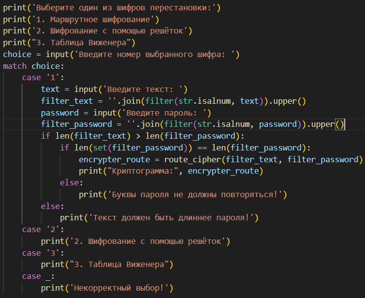

Начало реализации маршрутного шифрования

## Реализация маршрутного шифрования

- Я реализовал русский алфавит для удобного заполнения массивов. Далее я реализовал функцию route_cipher, в которой создал матрицу размером с текст пользователя и шириной с его пароль.

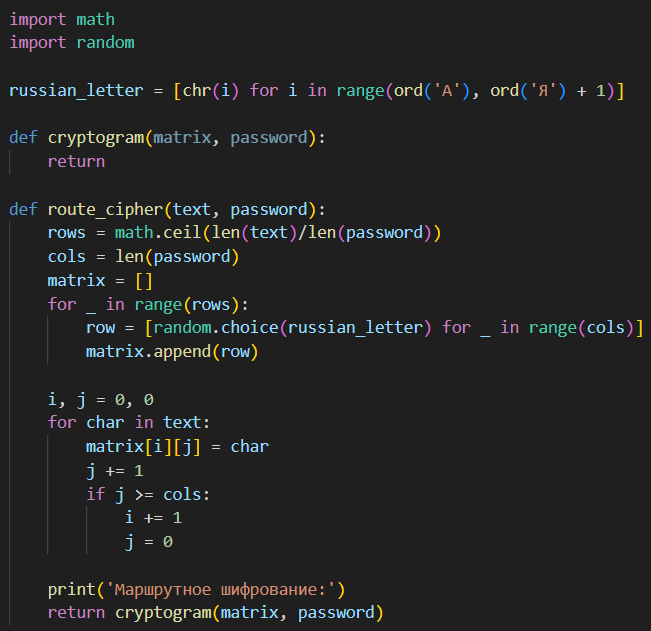

Реализация маршрутного шифрования

## Реализация маршрутного шифрования

- После я реализовал общую для первого и второго шифрования функцию cryptogram, которая из заданного массива и введённого пользователем пароля создаёт таблицу, которую выводит, а затем создаётся криптограмму.

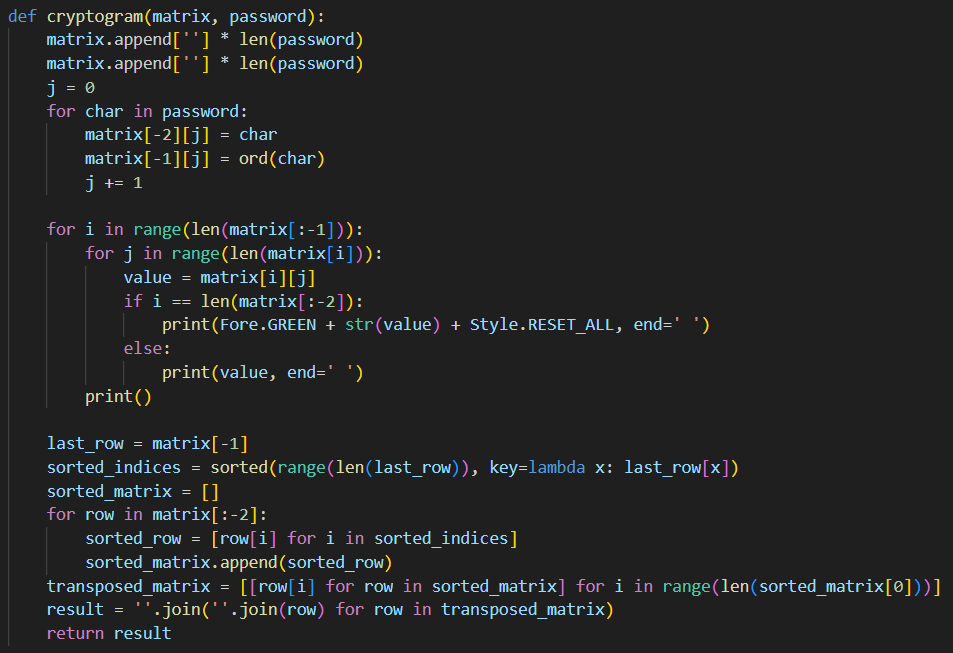

Реализация формирования криптограммы

## Реализация маршрутного шифрования

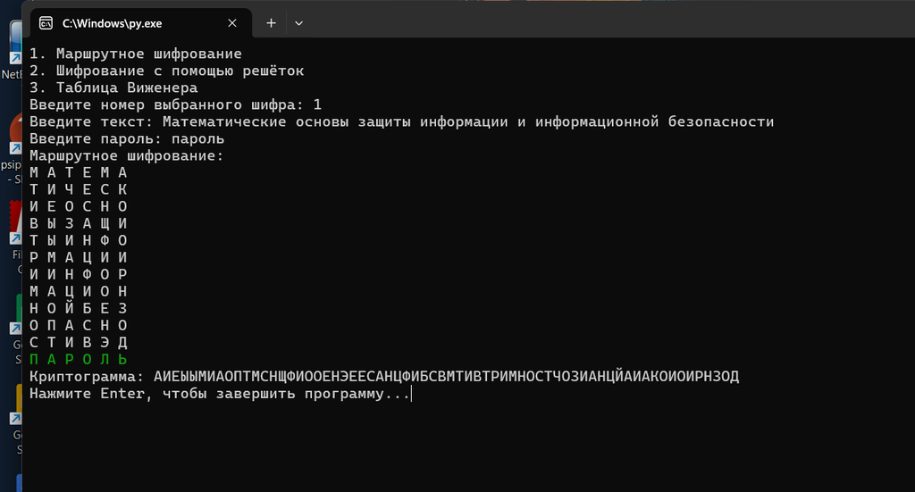

Проверка реализации маршрутного шифрования

## Реализация шифрования с помощью решёток

- Затем я перешёл к реализации шифрования с помощью решёток. Я аналогично предыдущему шифрованию запросил текст у пользователя, но в данном случае я запрашиваю пароль необходимой длины 2k, как сказано в теории к лабораторной работы.

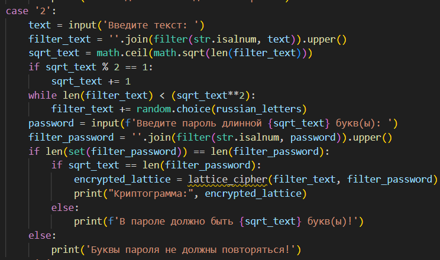

Начало реализации шифрования с помощью решёток

## Реализация шифрования с помощью решёток

- Далее я реализовал функцию lattice_cipher, в которой я создал матрицу размера 2k и заполнил её нулями.

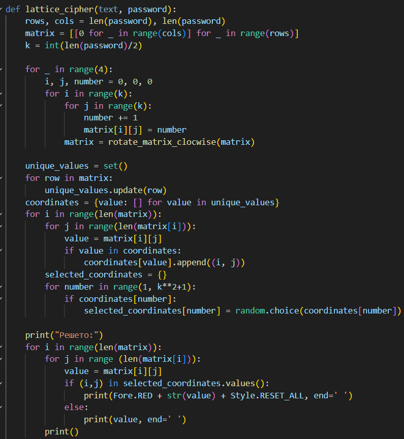

Реализация шифрования с помощью решёток

## Реализация шифрования с помощью решёток

- Для того чтобы заполнить матрицу значениями от 1 до k**2, я реализовал функцию вращения матрицы на 90 градусов по часовой стрелке.

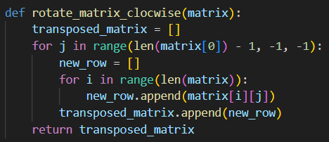

Функция вращения матрицы на 90 градусов по часовой стрелк

## Реализация шифрования с помощью решёток

- Далее для правильного заполнения матрицы текстом пользователя, я реализовал 4 похожих, но разных цикла. Я заполнял все уникальные значения побуквенно текстом пользователя.

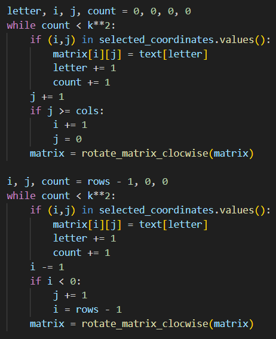

Первый и второй цикл заполнения матрицы текстом пользователя

## Реализация шифрования с помощью решёток

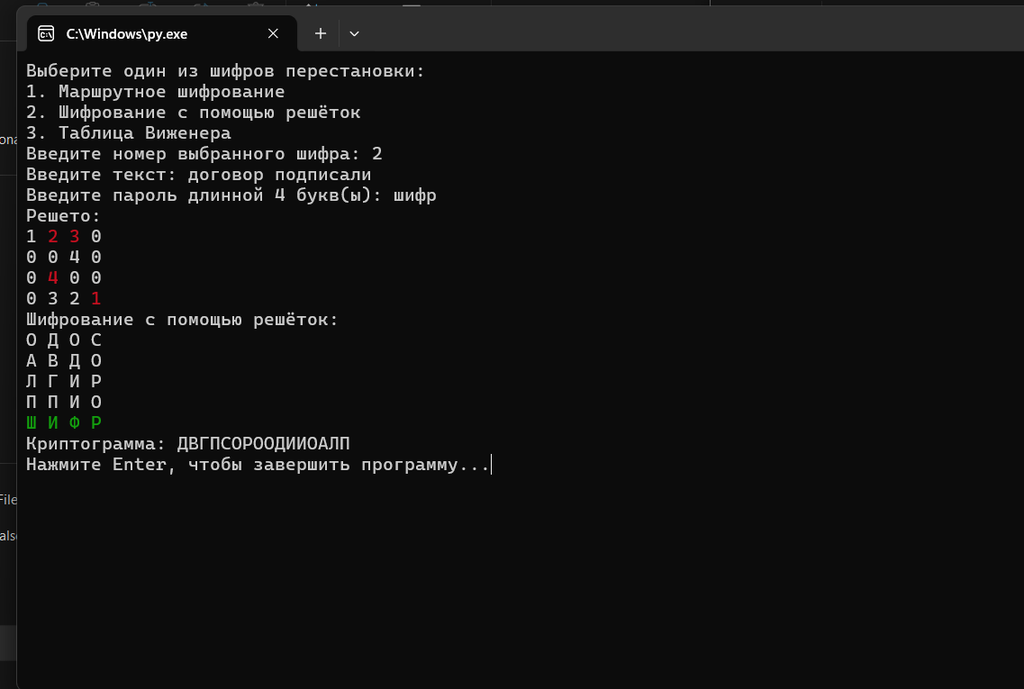

## Реализация шифра Виженера

- В конце я перешёл к реализации шифра Виженера. В первую очередь для его реализации нам потребуется таблица с русским алфавитом, где каждая следующая строка сдвигается на одну букву.

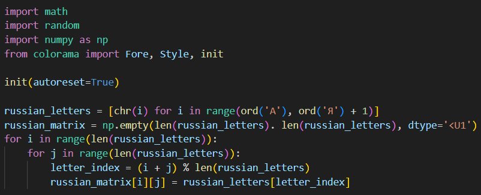

Реализация таблицы с русским алфавитом

## Реализация шифра Виженера

- Затем я перешёл к реализации шифра Виженера. Я аналогично предыдущим шифрованиям запросил текст и пароль у пользователя, отфильтровал их, а также проверил на соответствие требованиям для шифрования.

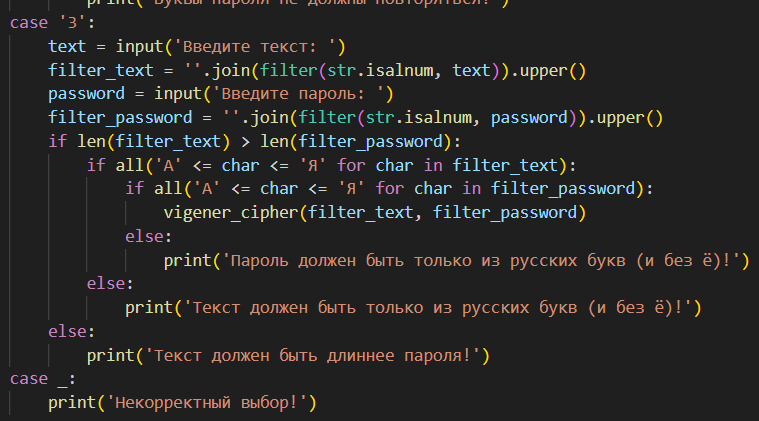

Начало реализации шифра Виженера

## Реализация шифра Виженера

- Далее я реализовал функцию vigener_cipher, в которой создаётся матрица, где первая строка - текст пользователя, вторая строка - повторяющийся пароль пользователя, а третья строка пуста (для будущей криптограммы).

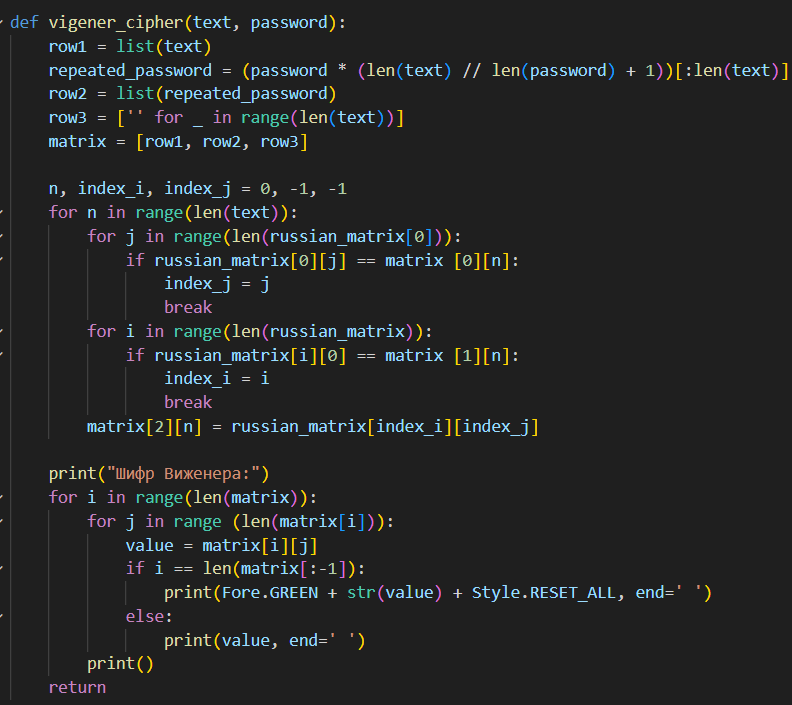

Реализация шифра Виженера

## Реализация шифра Виженера

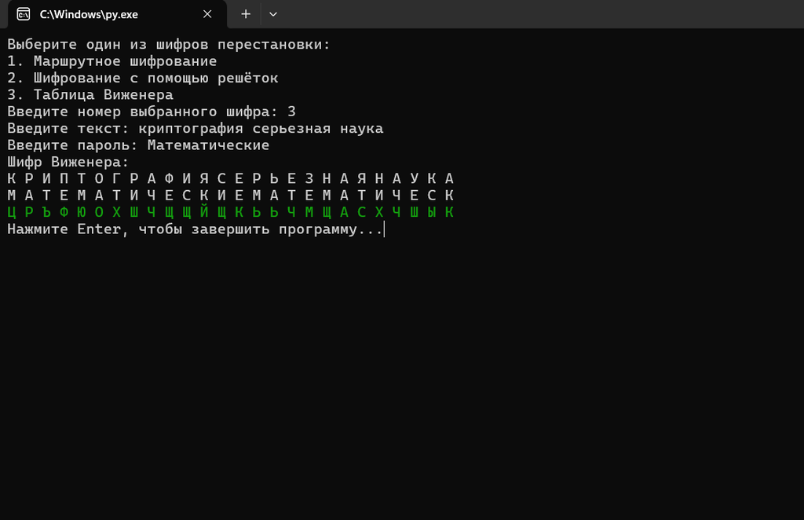

Проверка реализации шифра Виженера

## Выводы

- Я программно реализовал шифры перестановки.